# Top 10 Baby Names in CA years 1920-2020

Micky Steinberg

9/20/2021

### The Name Data

We start with the dataframe `CA.csv` from SSA.gov, which contains information about the number of children born with a given name, grouped by year and sex. The `popularity_index` refers to the percent of children (of the given sex) born that year with a given name. Note that the popularity index is computed as the proportion of total number of babies reported by the SSA for a given year, which is slightly smaller than the true number of babies, as the SSA only includes names given to at least 5 babies in a given year. The true number of babies born is approximately .5% or 1.5% greater (for males and females, respectively), and doesn’t fluctuate drastically from year to year.

Now we will define a “True Popularity Index” of a name in a given year. This will be the approximate popularity of a name within it’s *generation* - that is, the prevalence of the name within a window of 5 years. I.e. for the year 1920, the popularity index is the (approximate) percent of children (of the given sex) born from 1918 to 1922 with the given name, and the ranking is determined by the number of children (of the given sex) born in that time frame with the given name.

| sex | year | name | num_named | total_born | rank | popularity_index |
| --- | --- | --- | --- | --- | --- | --- |
| F | 1920 | Mary | 7440 | 135874 | 1 | 5.475661 |
| F | 1920 | Dorothy | 5069 | 135874 | 2 | 3.730662 |
| F | 1920 | Helen | 3471 | 135874 | 3 | 2.554573 |
| F | 1920 | Margaret | 3435 | 135874 | 4 | 2.528078 |
| F | 1920 | Betty | 3103 | 135874 | 5 | 2.283733 |
| F | 1920 | Virginia | 2958 | 135874 | 6 | 2.177017 |

| sex | year | name | num_named | total_born | rank | popularity_index |
| --- | --- | --- | --- | --- | --- | --- |
| M | 1920 | Robert | 8427 | 128075 | 1 | 6.579738 |
| M | 1920 | John | 6614 | 128075 | 2 | 5.164162 |
| M | 1920 | William | 6090 | 128075 | 3 | 4.755026 |
| M | 1920 | George | 4244 | 128075 | 4 | 3.313683 |
| M | 1920 | James | 3963 | 128075 | 5 | 3.094281 |
| M | 1920 | Frank | 3188 | 128075 | 6 | 2.489167 |

### Top names by popularity index over time

First we’ll just consider the popularity index of top names over time, that is, the proportion of children (by generation) over time with a top 10 name.

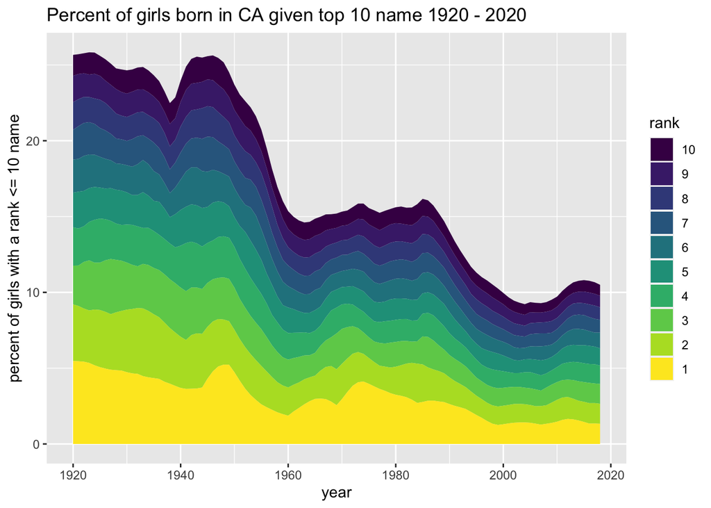

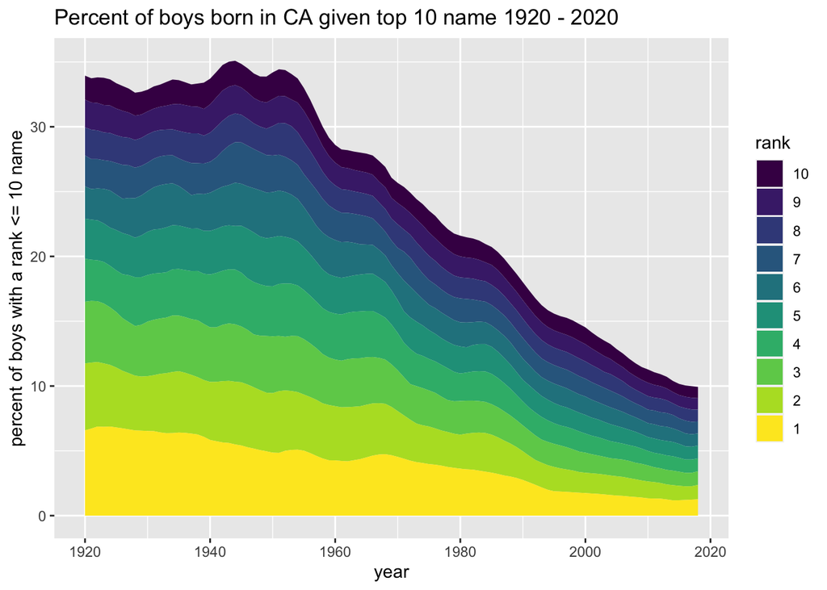